# EDA on Prosper Loan Data

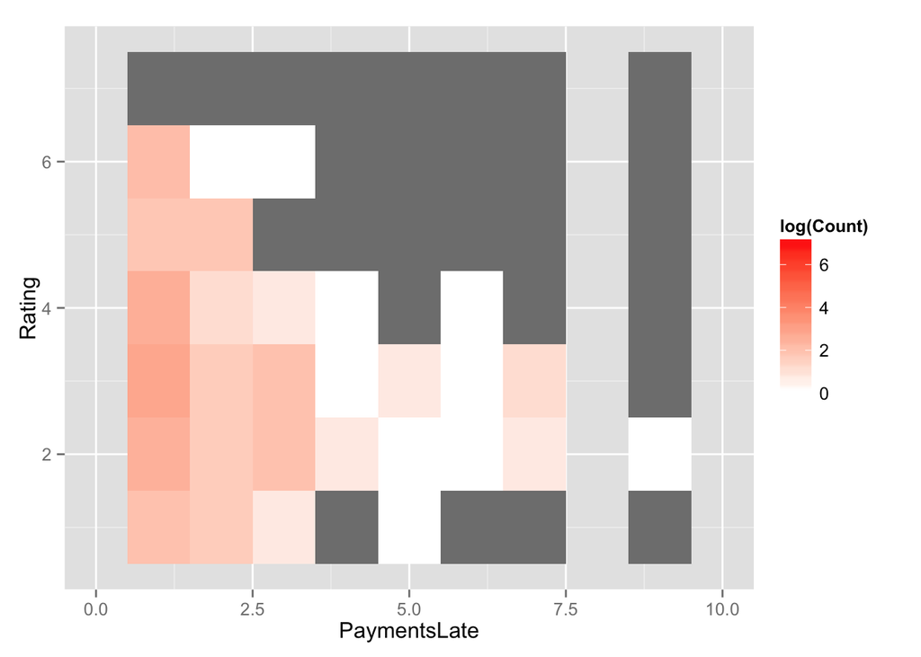

PaymentsLate should also be an indication where higher payments late by borrower should seen as bad rating. However, prosper rating shown weak relationship, although the outliers shown an indication stated.

```
## df$Homeowner: False
##    Min. 1st Qu.  Median    Mean 3rd Qu.    Max.
##       0    2917    4167    4876    6000  394400
## --------------------------------------------------------
## df$Homeowner: True
##    Min. 1st Qu.  Median    Mean 3rd Qu.    Max.
##       0    4167    5833    6885    8167 1750000
```

Then I try faceting the homeowner categorical by monthly salary. What I see is that salary is higher to home owner people to those who don’t. Since we know that the income is long tail right skewed, mean is not representing most people. Instead median do. In this summary we see that both median and mean both higher for home owner people in term of income.

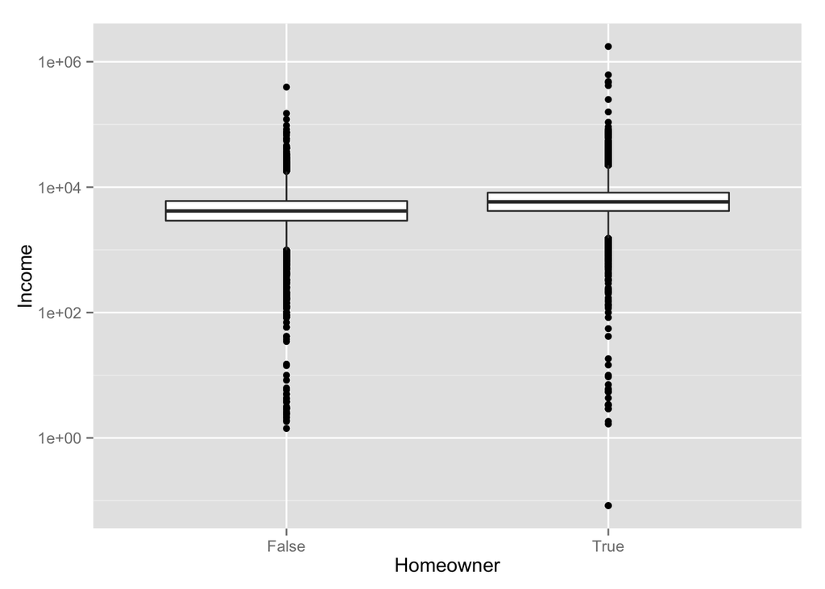

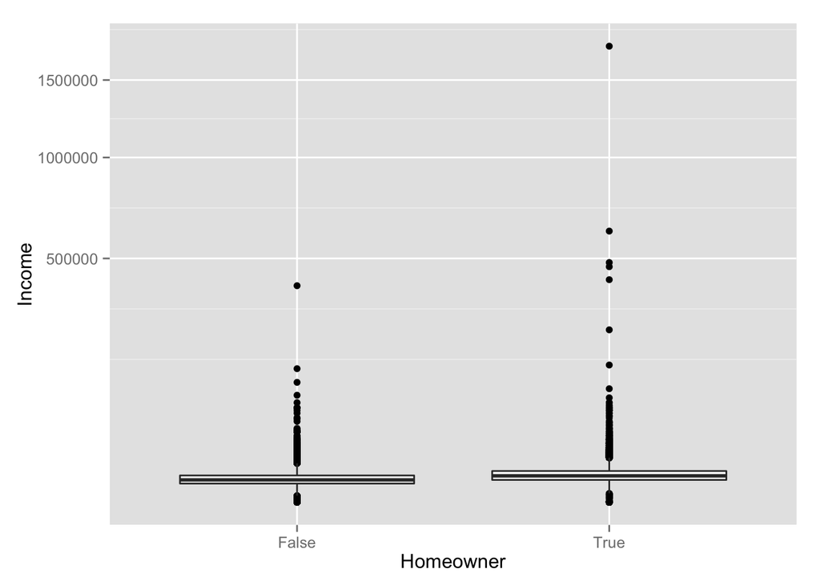

There you go, now it looks like the people who home owner still have higher median salary. still there’s many of outliers in both boxplot, since we expect that the income is long tail.

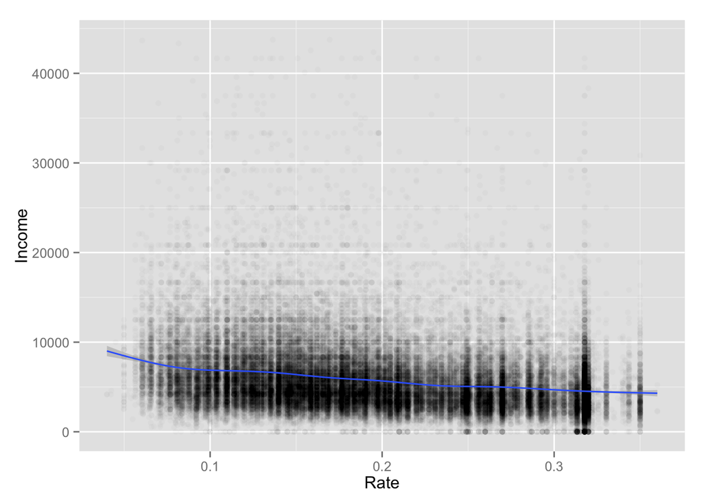

```
##
##  Pearson's product-moment correlation
##
## data:  df$Rate and df$Income
## t = -22.813, df = 66934, p-value < 2.2e-16
## alternative hypothesis: true correlation is not equal to 0
## 95 percent confidence interval:
##  -0.09534881 -0.08031441
## sample estimates:
##         cor
## -0.08783661
```

I see no relationship betwen both relationship. We can see that in the figure as interest rate increase, shows no sign of increase in the borrower’s income. Additionally, the correlation also approximate to zero which shows almost no correlation. Interestingly, when I add a regression line, I can see that income slightly decrease as the interest rate increase. So we see in regression line based on the data, people with lower income tend to have higher interest rate.

# Bivariate Analysis

### Talk about some of the relationships you observed in this part of the investigation. How did the feature(s) of interest vary with other features in the dataset?

Almost all of them has no strong relationship with the prosper rating. Interest rate however shows strong relationship to prosper rating. Based on data, borrowers’ interes rate explains 91.15% of the variance in prosper rating.

### Did you observe any interesting relationships between the other features (not the main feature(s) of interest)?

When observing the relationship between whether person is homeowner and their monthly stated income, it’s becoming clear that those who have home has higher income both median and mean. Observing the data, with median, salary of homeowner is 1700 dolars higher than those who doesn’t have a home.

### What was the strongest relationship you found?

The strongest relationship shown by interest rate and rating, with negative strong linear relationship. The second one is relationship with original loan amount and the rating, which shows positive moderately strong linear relationship. Both loan amount and interest rate can be used when want to infer rating, since it moves in the opposite direction.

# Multivariate Plots Section

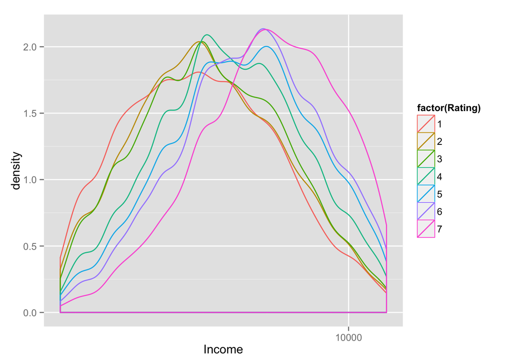

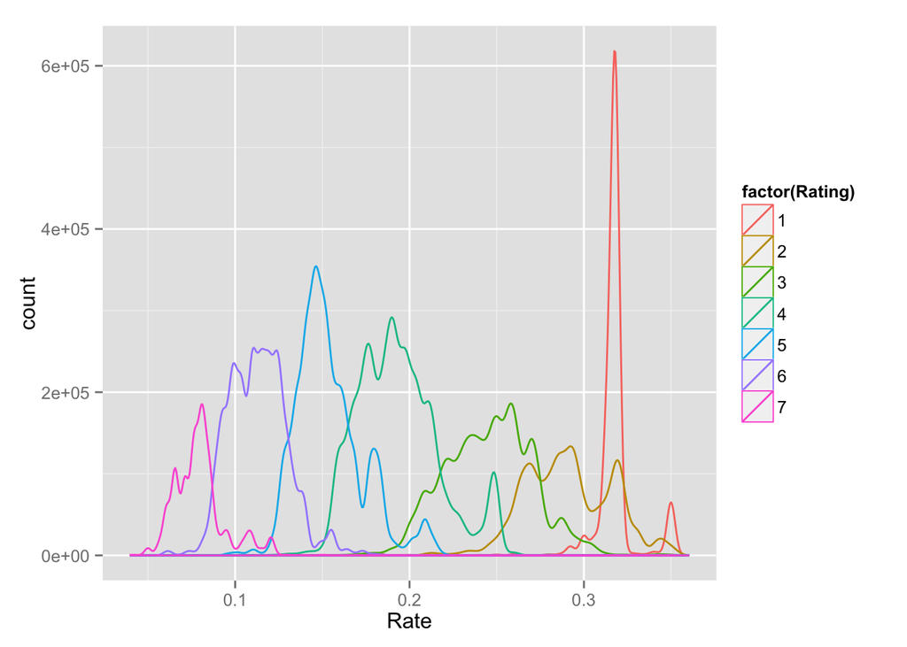

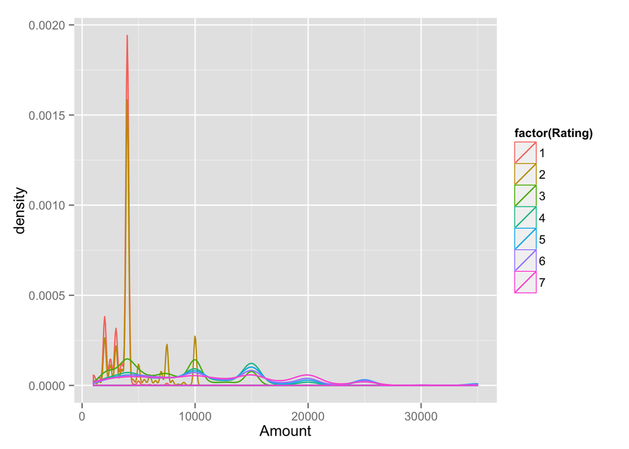

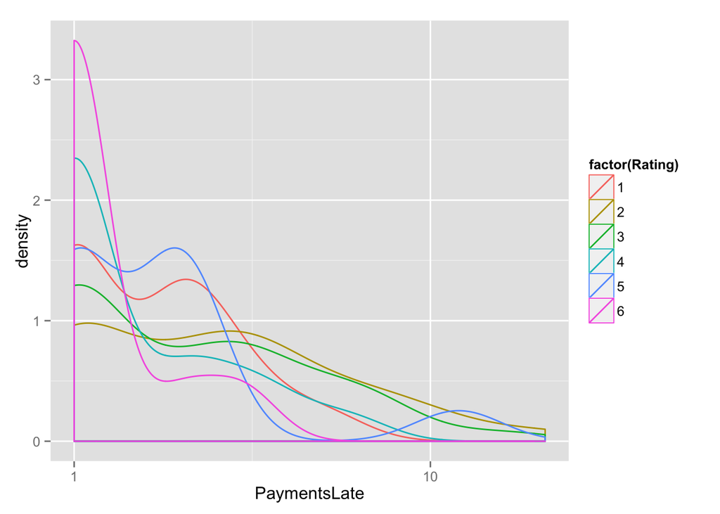

I see that the Income now affects the rating as well, but not with a wide margin. The lowest rating is peak around the center of the Income. but as the rating goes up, the center of the income turns out also change, shifted towards the right making it left skewed distribution.

While it also apparent that the lower the rating, the rarer it is based on the density plot. Note that we have huge peak for rating lowest rating when I plot it against interest rate and loan amount. 1 is HR in the prosper rating, which means high risk. Interestingly, we see that borrower with high interest rate, will receive low rating from Prosper.

But that is not the case with the loan amount. Even if the loan amount is really high, doesn’t make it high risk.

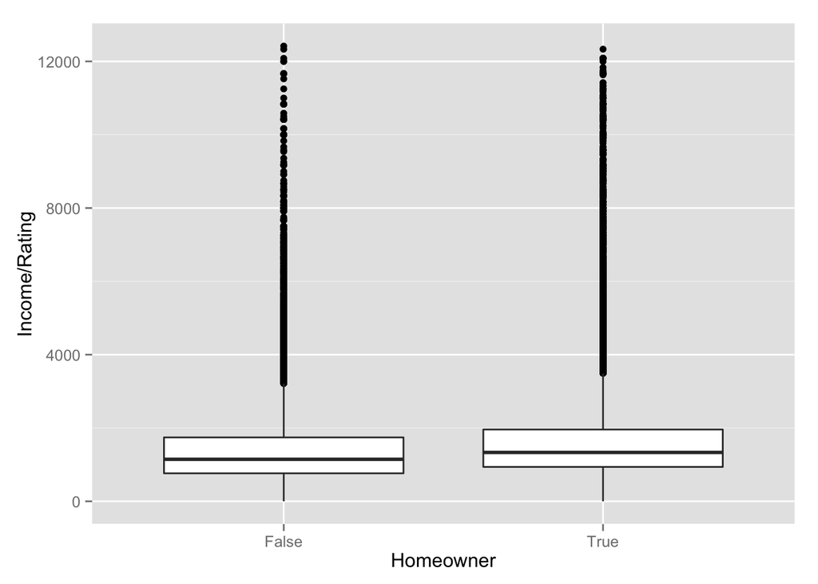

Income/rating shown no unusual difference when plotting against homeowner.

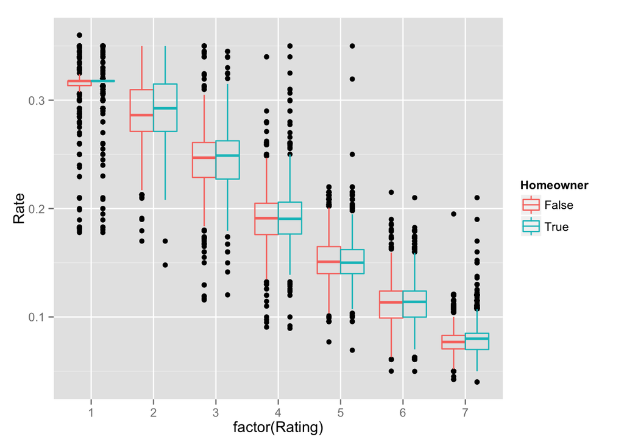

# Multivariate Analysis

### Talk about some of the relationships you observed in this part of the investigation. Were there features that strengthened each other in terms of looking at your feature(s) of interest?

Monthly income indeed strengthen the Prosper rating. We see that the center of the distribution between each rating is shifted to the right everytime the rating is going up.

### Were there any interesting or surprising interactions between features?

High amount of loans should generate high risk, since it’s risky if someone doesn’t pay the the loans. But here the rating doesn’t event consider the loan amount. Even the opposite, low loan amount could generate higher risk.

## Final Plots and Summary

### Plot One

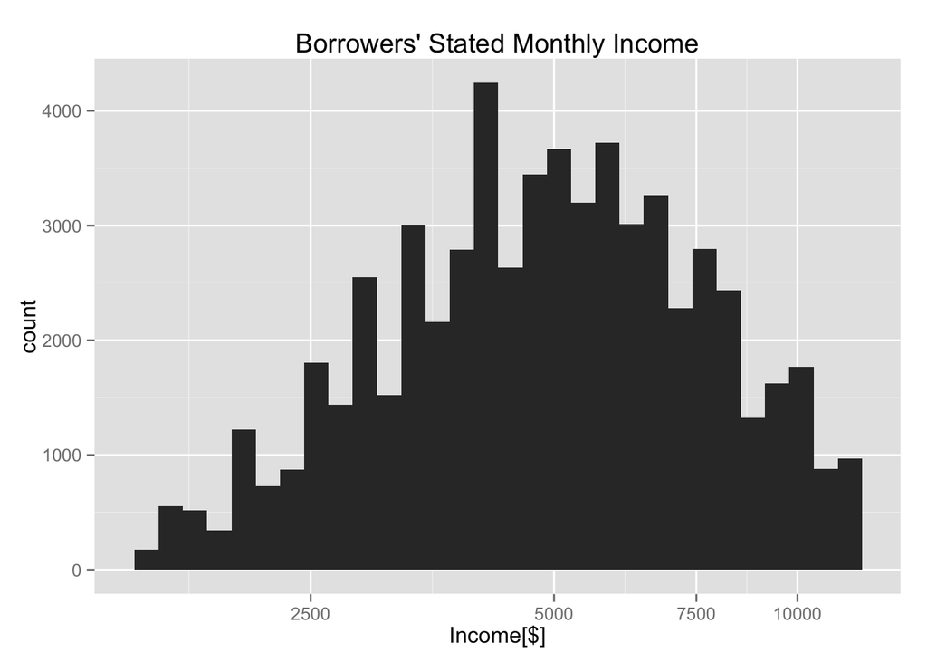

```
##    Min. 1st Qu.  Median    Mean 3rd Qu.    Max.
##       0    3430    5000    5935    7083 1750000
```

```
## [1] 4000
```

### Description One

I choose histogram since income is numerical variable. Histogram is used when we want to see the distribution.Salary Income is expected to be highly right skewed, since fewer and fewer people have higher salary. But it’s human input, so it’s expected to be an outlier as well. After exclude the outliers and log10 scale the income, we have tidier normal distribution.

Since this is right skewed, I use quantiles to describe it more statiscally. We see that minimum monthly salary is 0, and this is not to be expected. Income is stated manually by the borrower, so there’s some users that prefer not to fill it in, and it’s default to zero. The other thing is where most of the users in the interquartile range is in thousands, there are income that flies as high as 1.75 million but makes loan of 4000 dolars. Clearly person that have this income shouldn’t make such a low loan. And since this is human input, there’s high chance this person is not being honest. Because of this distribution and outliers stated, I choose to log10 scale to make it normal distribution.

### Plot Two

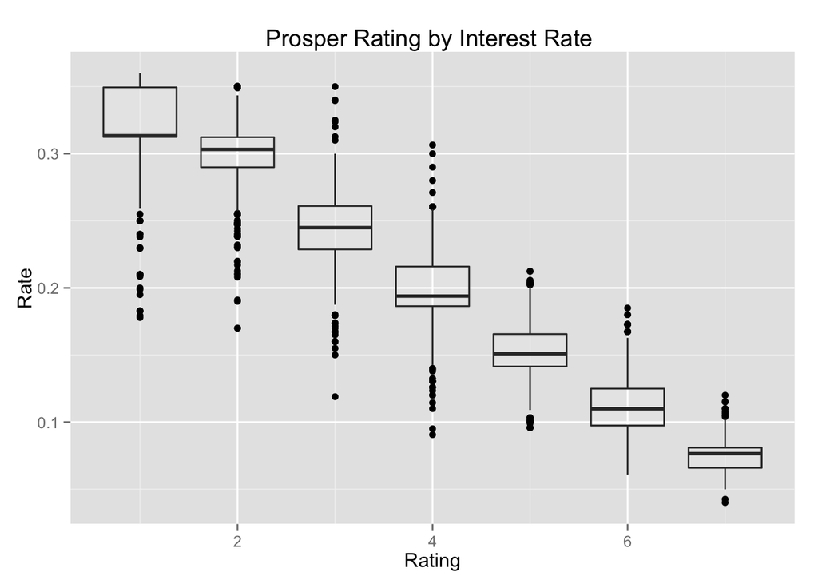

```
##
##  Pearson's product-moment correlation
##
## data:  df$Rate and df$Rating
## t = -830.36, df = 66934, p-value < 2.2e-16
## alternative hypothesis: true correlation is not equal to 0
## 95 percent confidence interval:
##  -0.9553976 -0.9540569
## sample estimates:
##        cor
## -0.9547321
```

### Description Two

Looking at the statistics, Prosper Rating is strongly correlated with borrower’s interest rate, with negative linear relationship. This is the highest correlation among the all other features. This suggest that as interest rate decrease, the Prosper Rating receive higher grade, and with R^2 of 0.91, means that 91% of Prosper rating variance can be explain by borrower’s interest rate in the data.

I use box plot and differentiate the charts by Prosper Rating. The reason to do this is I want to see skewed distribution of borrowers’ interest rate across Prosper Rating. Looking at the chart, the lowest Prosper rating have highest median of interest rate. It has no outliers in above Q3. Meanwhile the highest rating has the smallest IQR compared to the rest of the rating. This suggest that the interest rate in smallest rating only in small range. If we observe summary statistics of interest rate at highest rating,

```
##    Min. 1st Qu.  Median    Mean 3rd Qu.    Max.
##  0.0400  0.0704  0.0789  0.0797  0.0849  0.2100
```

We see that the interest rate is minimum at 0.04, and only as high as 0.21

### Plot Three

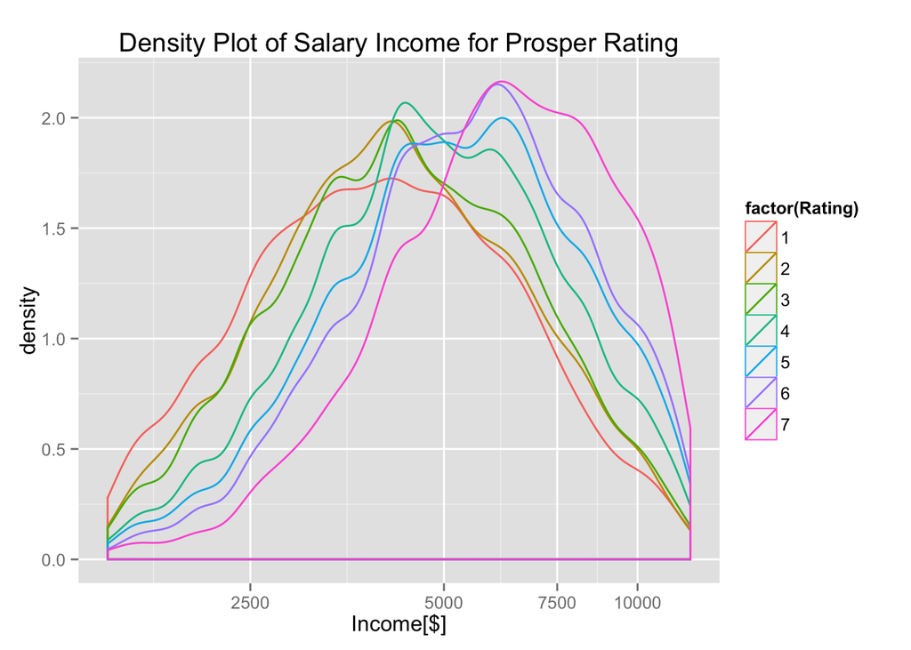

### Description Three

I choose density plot to see where distribution is centered as Prosper Rating increase. While it’s not a very distinct trend, we see that the center of the distribution, is shifted towards the right when the rating goes higher. We can’t see the normal distribution like this unless we exclude 5% and 95% quantiles, and also log10 scale the income.

```
##
##  Pearson's product-moment correlation
##
## data:  df$Income and df$Rating
## t = 22.654, df = 66934, p-value < 2.2e-16
## alternative hypothesis: true correlation is not equal to 0
## 95 percent confidence interval:
##  0.07970669 0.09474270
## sample estimates:
##        cor
## 0.08722966
```

Eventhough we see some different trend in the density plot, The correlation test shows weak positive linear relationship.

## Reflection

Occupation and Listing Category should be the features for predicting Prosper rating. But this is hard since both have many categorical variable. People with more interesting job could have higher rating. But too many occupation have `Other` and `Professional` which is hard to defined. While listing category could also plays important role, this is also has too many categorical level. The significant of both variables with Prosper Rating can be tested using ANOVA, but it’s outside the scope of the analysis. This analysis also succeed in selecting the features and the correlation with the feature of interest, which in this case is Prosper Rating. There is whole 81 features in the dataset, and I only select 13 variables in this dataset. It’s interesting additional features to predict the rating of the Prosper system.